# EMBL-EBI Cancer genomics and transcriptomics course: Mutational signatures analysis

Francesc Muyas, PhD

11/07/2023

# Mutational signatures analysis: *de novo* mutational signature extraction

During this practical session, we will focus on the detection and interpretation of mutational signatures in real samples. Particularly, you’ll perform the *de novo* signature extraction and signature identification.

The data used in this section is publicly available WES data generated from Ji et at. 2020 and somatic mutation calls provided in the [*MutationalPatterns*](https://bioconductor.org/packages/release/bioc/html/MutationalPatterns.html) package. The somatic variant calling for the Ji et al 2020 data was performed using Strelka2.

To run all these analysis, we will work with the R package [*MutationalPatterns*](https://bioconductor.org/packages/release/bioc/html/MutationalPatterns.html).

### Preparing and loading the data

### Required packages

```r
#---
# Loading required packages
#---
suppressWarnings(library(data.table))
suppressWarnings(library(BSgenome))
ref_genome <- "BSgenome.Hsapiens.UCSC.hg38"
suppressWarnings(library(ref_genome, character.only = TRUE))
suppressWarnings(library(GenomicRanges))
suppressWarnings(library(MutationalPatterns))
suppressWarnings(library(plyr))
suppressWarnings(library(NMF))
```

### Functions to load vcf.gz Strelka2 files

This function can open the Strelka2 somatic calls ( *vcf.gz* with SNVs) and extract the VAF, DP, number of alternative alleles…

```r
# Function to load snp.vcf.gz from Strelka2
Load_vcf <- function(vcf_file){
  VCF <- as.data.frame(fread(cmd = paste("zgrep -v '##' ", vcf_file, sep = ''), sep = '\t'))
  VCF <- dplyr::rename(VCF, CHROM = `#CHROM`)
  VCF <- VCF[VCF$CHROM %in% c(paste('chr',seq(1,22), sep = ''),'chrX','chrY'),]

  # Parse the vcf to extract alternative counts
  # We keep only the PASS mutations
  VCF2 <- VCF[VCF$FILTER == 'PASS',]

  # Extract normal alternative counts
  VCF2 <- tidyr::separate(data = VCF2, col = NORMAL, sep = ':',
                          into = c('N_DP','N_FDP','N_SDP','N_SUBDP','N_AU','N_CU','N_GU','N_TU'))
  VCF2$N_REF_COUNT <- apply(VCF2, 1, function(x) as.numeric(unlist(strsplit(x = x[paste('N_',x['REF'],'U', sep = '')], split = ','))[1]))
  VCF2$N_ALT_COUNT <- apply(VCF2, 1, function(x) as.numeric(unlist(strsplit(x = x[paste('N_',x['ALT'],'U', sep = '')], split = ','))[1]))
  VCF2$N_DP <- as.numeric(VCF2$N_DP) # We want this value to be considered as a number

  # Extract tumour alternative counts
  VCF2 <- tidyr::separate(data = VCF2, col = TUMOR, sep = ':',
                          into = c('T_DP','T_FDP','T_SDP','T_SUBDP','T_AU','T_CU','T_GU','T_TU'))
  VCF2$T_REF_COUNT <- apply(VCF2, 1, function(x) as.numeric(unlist(strsplit(x = x[paste('T_',x['REF'],'U', sep = '')], split = ','))[1]))
  VCF2$T_ALT_COUNT <- apply(VCF2, 1, function(x) as.numeric(unlist(strsplit(x = x[paste('T_',x['ALT'],'U', sep = '')], split = ','))[1]))
  VCF2$T_DP <- as.numeric(VCF2$T_DP) # We want this value to be considered as a number

  # Too many columns for now, let's keep only the important ones
  VCF3 <- VCF2[,c('CHROM','POS','REF','ALT','QUAL','FILTER','N_DP','N_REF_COUNT','N_ALT_COUNT','T_DP','T_REF_COUNT','T_ALT_COUNT')]

  # Compute Variant Allele Frequency (VAF) in the matched normal sample
  VCF3$N_VAF <- VCF3$N_ALT_COUNT/VCF3$N_DP
  # Compute Variant Allele Frequency (VAF) in the tumour sample
  VCF3$T_VAF <- VCF3$T_ALT_COUNT/VCF3$T_DP
  return(VCF3)
}
```

### Loading all data

We will load publicly available data from other studies (9 cSCC cancer samples).

Let’s first of all check the number of files that we will load. **Please edit the path of DATA_FOLDER to the path of your data**

```r
# Directory with the Strelka2 calls
# Please edit this path to the desired one in your computer
DATA_FOLDER <- '~/Documents/EMBL/CancerGenomicsCourse2023/mutational_signatures_data/'

files <- list.files(path=DATA_FOLDER, pattern = '*snvs.vcf.gz$', recursive = T)
files <- paste(DATA_FOLDER,files, sep = '/')
files <- files[!grepl('COLO', x = files)]

length(files)
```

```
## [1] 9
```

In order to save the calls of all these files in a single data frame automatically, we will use the next for loop:

```r
count <- 1
Mut_calls <- NULL
for (file in files){
  # Load vcf.gz file
  # Function previously defined
  a <- Load_vcf(file)

  # Get sample ID
  # We extract the sample name from the full path
  sampleID <- rev(unlist(strsplit(x = file, split = '/')))[3]

  if (nrow(a) > 0){
    a <- cbind(sampleID,a)

    Mut_calls[[count]] <- a

    count <- count + 1
  }
}

# Usually faster than rbind in each iteration of the for loop
Mut_calls <- do.call("rbind", Mut_calls)
```

Let’s check the first lines and dimensions of the generated data frame

```r
head(Mut_calls)
```

```
##    sampleID CHROM     POS REF ALT QUAL FILTER N_DP N_REF_COUNT N_ALT_COUNT T_DP
## 8  P10_cSCC  chr1 1197539   C   T    .   PASS  106         105           0  157
## 22 P10_cSCC  chr1 2504937   G   A    .   PASS  102         101           0  151
## 33 P10_cSCC  chr1 3868019   G   C    .   PASS  192         191           0  336
## 38 P10_cSCC  chr1 6051593   T   G    .   PASS   62          61           0  104
## 40 P10_cSCC  chr1 6110464   G   A    .   PASS  103         103           0  171
## 42 P10_cSCC  chr1 6142137   G   A    .   PASS  249         248           0  445
##    T_REF_COUNT T_ALT_COUNT N_VAF      T_VAF
## 8          151           5     0 0.03184713
## 22         146           5     0 0.03311258
## 33         320          15     0 0.04464286
## 38          99           5     0 0.04807692
## 40         166           5     0 0.02923977
## 42         432          13     0 0.02921348
```

```r
dim(Mut_calls)
```

```
## [1] 21215    15
```

### Filtering mutations

We will only analyse mutations in the autosomal chromosomes and with coverage >= 10 in the tumour samples:

```r
# Let's focus on the autosomal chromosomes
Mut_calls <- Mut_calls[Mut_calls$CHROM %in% paste('chr',seq(1,22), sep = ''),]
# At least a depth of coverage of 10x
Mut_calls <- Mut_calls[Mut_calls$T_DP >= 10,]
dim(Mut_calls)
```

```
## [1] 20475    15
```

### Let’s add some samples from other cancers

These samples are the examples samples provided in the [*MutationalPatterns*](https://bioconductor.org/packages/release/bioc/html/MutationalPatterns.html) package. However, we did a liftover of the genome to have all of them with the Hg38 coordinates. **Please edit the path of this file to the one you downloaded from github**

```r
# Please edit the path of this file to the one you downloaded from github
EXTRA <- as.data.frame(fread('~/Documents/EMBL/CancerGenomicsCourse2023/mutational_signatures_data/Extra_samples/ExtraSamples.Hg38.tsv'))
table(EXTRA$sampleID)
```

```
##
##     colon1     colon2     colon3 intestine1 intestine2 intestine3     liver1
##        196        600        450        150        800        500        300
##     liver2     liver3
##        900        200
```

Merge these mutations with the previously loaded ones:

```r
Mut_calls <- rbind.fill(Mut_calls,EXTRA)
```

## Mutation characteristics

In this example today, we will focus on SNVs. This package ( *MutationalPatterns*), works with *GRanges* objects. For these reasons, we will transform our data frame with mutations into a *GRanges* object:  
It can be done with this function:

```r
# Transform data.frame to genomic ranges object
# Create list of granges
GRmaker <- function(CALLS,GROUP){
  TEMP <- CALLS[CALLS$GROUP == GROUP,]
  GR <- with(TEMP, GRanges(CHROM, ranges=IRanges(POS, POS), REF = REF,ALT = ALT))
  seqlevelsStyle(GR) <- "UCSC"
  GenomeInfoDb::genome(GR) <- 'hg38'
  return (GR)
}
```

Once defined this function, we can execute it using our mutations data frame:

```r
# This column will specify how to group the mutations
# For now, we use the sampleID, but it can be modified
Mut_calls$GROUP <- Mut_calls$sampleID

# Create list of granges
GROUPS <- unique(Mut_calls$GROUP)
G_lists <-  lapply(GROUPS, function(x) GRmaker(Mut_calls, x))
names(G_lists) <- GROUPS
```

Take a look at the new object

```r
names(G_lists)
```

```
##  [1] "P10_cSCC"   "P2_cSCC"    "P3_cSCC"    "P4_cSCC"    "P5_cSCC"
##  [6] "P6_cSCC"    "P7_cSCC"    "P8_cSCC"    "P9_cSCC"    "colon1"
## [11] "colon2"     "colon3"     "intestine1" "intestine2" "intestine3"
## [16] "liver1"     "liver2"     "liver3"
```

```r
head(G_lists,2)
```

```
## $P10_cSCC
## GRanges object with 1637 ranges and 2 metadata columns:
##          seqnames    ranges strand |         REF         ALT
##             <Rle> <IRanges>  <Rle> | <character> <character>
##      [1]     chr1   1197539      * |           C           T
##      [2]     chr1   2504937      * |           G           A
##      [3]     chr1   3868019      * |           G           C
##      [4]     chr1   6051593      * |           T           G
##      [5]     chr1   6110464      * |           G           A
##      ...      ...       ...    ... .         ...         ...
##   [1633]    chr22  50570905      * |           G           A
##   [1634]    chr22  50721325      * |           G           A
##   [1635]    chr22  50721646      * |           C           T
##   [1636]    chr22  50721647      * |           A           T
##   [1637]    chr22  50722032      * |           C           T
##   -------
##   seqinfo: 22 sequences from hg38 genome; no seqlengths
##
## $P2_cSCC
## GRanges object with 1612 ranges and 2 metadata columns:
##          seqnames    ranges strand |         REF         ALT
##             <Rle> <IRanges>  <Rle> | <character> <character>
##      [1]     chr1    930302      * |           G           A
##      [2]     chr1    972934      * |           C           T
##      [3]     chr1   1212672      * |           G           A
##      [4]     chr1   1399688      * |           C           T
##      [5]     chr1   6097465      * |           G           A
##      ...      ...       ...    ... .         ...         ...
##   [1608]    chr22  49624485      * |           C           T
##   [1609]    chr22  49823173      * |           G           A
##   [1610]    chr22  50521583      * |           C           T
##   [1611]    chr22  50722231      * |           C           T
##   [1612]    chr22  50739773      * |           C           G
##   -------
##   seqinfo: 22 sequences from hg38 genome; no seqlengths
```

### Mutation spectrum

The mutation spectrum displays the proportionate contribution of each mutation type within the base substitution catalogs.  
With the function *mut_type_occurrences*, you can count mutation type occurrences for all VCF objects in the GRangesList:

```r
type_occurrences <- mut_type_occurrences(G_lists, ref_genome)
type_occurrences
```

```
##            C>A C>G  C>T T>A T>C T>G C>T at CpG C>T other
## P10_cSCC    70  33 1400  48  73  13        236      1164
## P2_cSCC     49  39 1344  44 115  21        254      1090
## P3_cSCC    143  73 3169 123 131  76        441      2728
## P4_cSCC     32  14  845  33  67  18        114       731
## P5_cSCC     53  27 1465  49  73  34        255      1210
## P6_cSCC     57  17  500  20  57  17        114       386
## P7_cSCC     99  43 3018  58 102  32        539      2479
## P8_cSCC    113  92 2599  66 118  57        394      2205
## P9_cSCC    118 207 3176  87 118  30        498      2678
## colon1      28   5  109  12  30  12         59        50
## colon2      77  29  345  37  90  22        209       136
## colon3      79  19  243  25  61  23        165        78
## intestine1  19   8   74  19  26   4         33        41
## intestine2 118  49  423  57 126  27        257       166
## intestine3  54  27  298  32  67  22        192       106
## liver1      43  22   94  30  77  34         18        76
## liver2     146  93  276 103 209  73         48       228
## liver3      39  28   62  15  32  24          7        55
```

The function *plot_spectrum* is responsible for generating a plot that showcases the average relative contribution of the six base substitution types across all samples. Error bars indicate the 95% confidence interval across all samples.

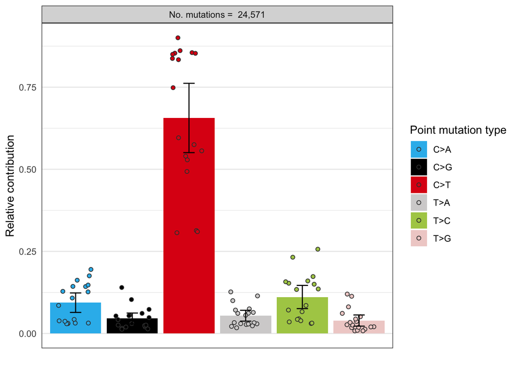

```r
p1 <- plot_spectrum(type_occurrences, indv_points = TRUE)
p1
```

### 96 mutation profile

The 96 mutation profile refers to a classification system that characterizes mutations based on the nucleotide context surrounding them. It considers all possible trinucleotide combinations (96 in total) and quantifies the frequency of specific mutation types within each context.

First we need to generate a 96 trinucleotide mutation count matrix using the function *mut_matrix*:

```r
mut_mat <- mut_matrix(vcf_list = G_lists, ref_genome = ref_genome)
head(mut_mat)
```

```
##         P10_cSCC P2_cSCC P3_cSCC P4_cSCC P5_cSCC P6_cSCC P7_cSCC P8_cSCC
## A[C>A]A        3       6      16       4       2       6       2      10
## A[C>A]C        2       4       6       2       1       2       6       9
## A[C>A]G        0       3       4       2       0       4       1       5
## A[C>A]T        4       1       3       0       1       1       3       3
## C[C>A]A        9       2      16       5       8       6      10       5
## C[C>A]C        5       8       9       0       3       1      12       5
##         P9_cSCC colon1 colon2 colon3 intestine1 intestine2 intestine3 liver1
## A[C>A]A       4      3     10     10          5         19          6      8
## A[C>A]C       7      0      3      3          1          8          4      1
## A[C>A]G       4      2      3      3          1          4          0      1
## A[C>A]T       4      0      2      9          0          9          2      2
## C[C>A]A      14      1      8      5          0          8          7      2
## C[C>A]C       6      2      5      3          1          3          2      1
##         liver2 liver3
## A[C>A]A     10      3
## A[C>A]C      8      2
## A[C>A]G      6      2
## A[C>A]T     12      2
## C[C>A]A     15      3
## C[C>A]C     16      2
```

Once we have this matrix, we can generate the 96 profile plots:

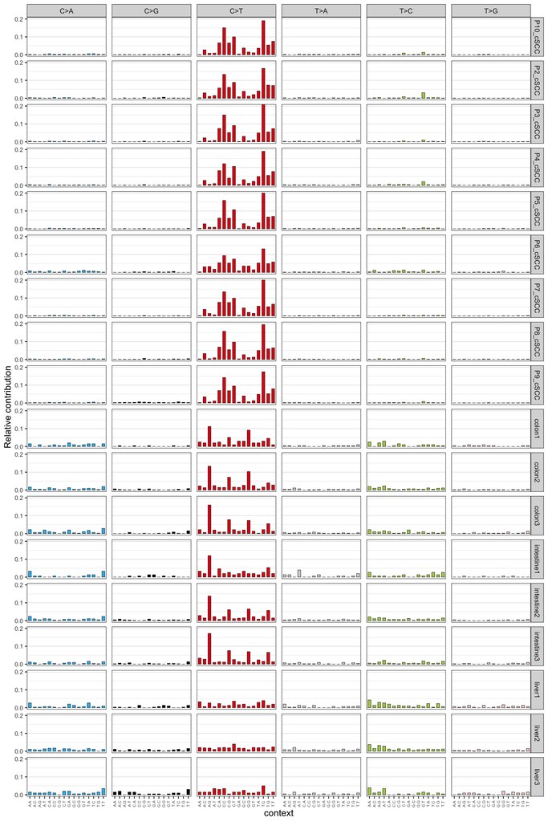

```r
# Plot with 96 profile context
Plot_96 <- plot_96_profile(mut_mat)
Plot_96
```

Interestingly, we can check larger contexts by computing different mutation matrixes:

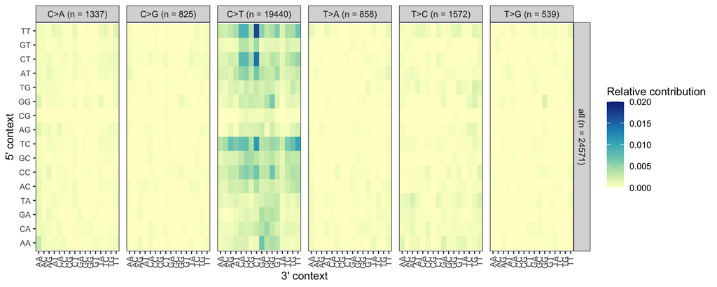

```r
# In this case, we take +-2 nucleotide context
mut_mat_ext_context <- mut_matrix(G_lists, ref_genome, extension = 2)
p2 <- plot_profile_heatmap(mut_mat_ext_context)
p2
```

### *De novo* mutational signature extraction using NMF

Mutational signatures are believed to depict underlying mutational processes and are characterized by their unique contribution of mutation types within specific sequence contexts. These signatures can be extracted from your mutation count matrix using a technique called non-negative matrix factorization (NMF).

#### Extracting the number of ranks (signatures)

In the context of NMF, an essential parameter is the factorization rank, which refers to the number of mutational signatures to be extracted. Determining the optimal factorization rank can be achieved by utilizing the NMF package. This package provides tools and methods to assist in identifying the most suitable factorization rank for the given analysis.

According to their paper: *“…The most common approach is to choose the smallest rank for which cophenetic correlation coefficient starts decreasing. Another approach is to choose the rank for which the plot of the residual sum of squares (RSS) between the input matrix and its estimate shows an inflection point…”*

```r
# First add a small pseudocount to your mutation count matrix
mut_mat <- mut_mat + 0.0001
estimate <- nmf(mut_mat, rank = 2:5, method = "brunet",
                nrun = 30, seed = 123456, .opt = "v-p")
```

Now, we can visualise the NMF results:

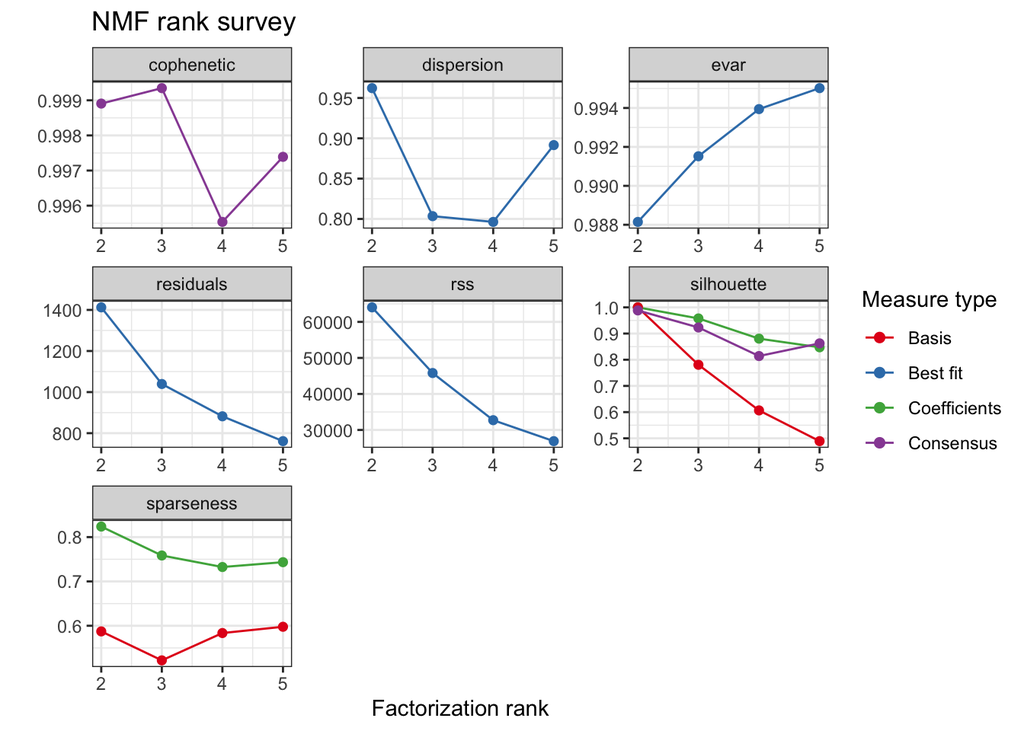

```r
plot(estimate)
```

Based on the previous plot, we can now extract the the number of signatures to fit. In this case rank = 3 (because it is the point where the cophenetic correlation coefficient starts decreasing).

```r
nmf_res <- extract_signatures(mut_mat, rank = 3, nrun = 10, single_core = TRUE)
```

We can name our extracted signatures:

```r
colnames(nmf_res$signatures) <- c("Signature A", "Signature B","Signature C")
rownames(nmf_res$contribution) <- c("Signature A", "Signature B","Signature C")
```

And visualise them:

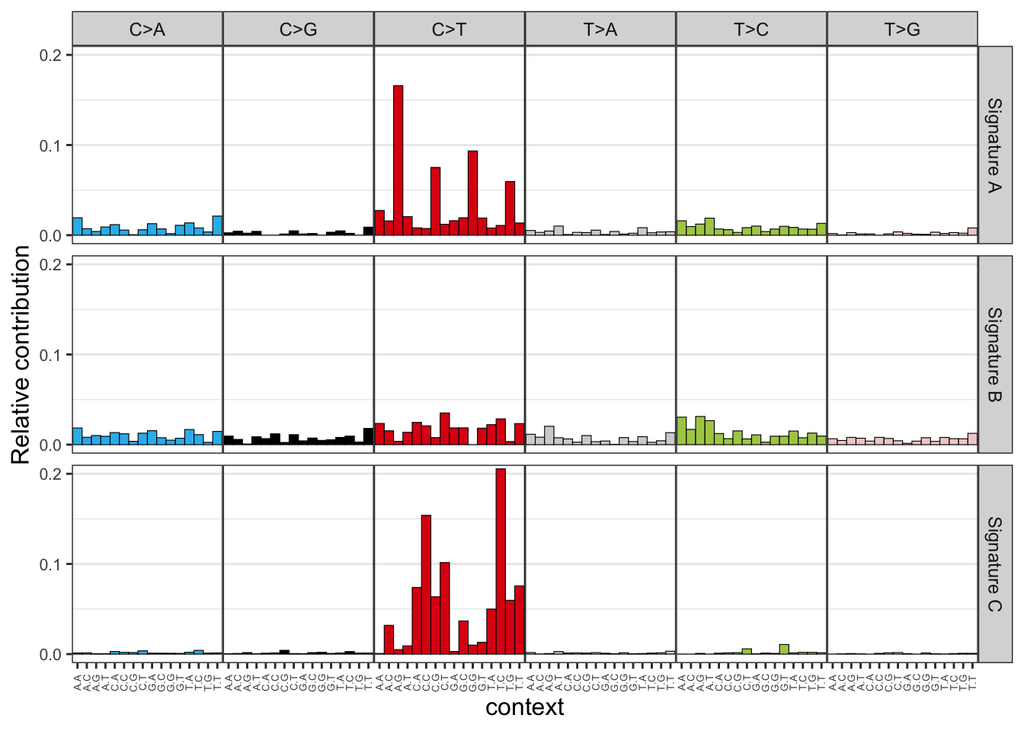

```r
# You can plot the 96-profile of the signatures (When looking at SNVs)
plot_96_profile(nmf_res$signatures, condensed = TRUE)
```

#### Signature identification

Now, we want to identify if the extracted mutational signatures have potential underlying biological processes that we can characterise. This involves comparing the extracted signatures with known reference signatures and determining the most similar matches based on various metrics (e.g., cosine similarity).

Although we already named our new signatures, we can load the COSMIC signatures and try to find if any of our extracted signatures is very similar to the known ones.

For that, we will compare them (usine cosine similarities) against the already known signatures in [COSMIC signatures (v3)](https://cancer.sanger.ac.uk/signatures/sbs/). We will change the name if they have a cosine similarity >= 0.85.

```r
# Getting known signatures
# COSMIC (v3.2) (Alexandrov et al. 2020)
signatures = get_known_signatures()

# Rename mutational signatures
nmf_res <- rename_nmf_signatures(nmf_res, signatures, cutoff = 0.85)
colnames(nmf_res$signatures)
```

```
## [1] "SBS1-like"  "SBS5-like"  "SBS7b-like"
```

**QUESTION**: Could you say something about the aetiology of the extracted signatures?

#### Visualizing the extracted signatures

We can now visualize the new signatures:

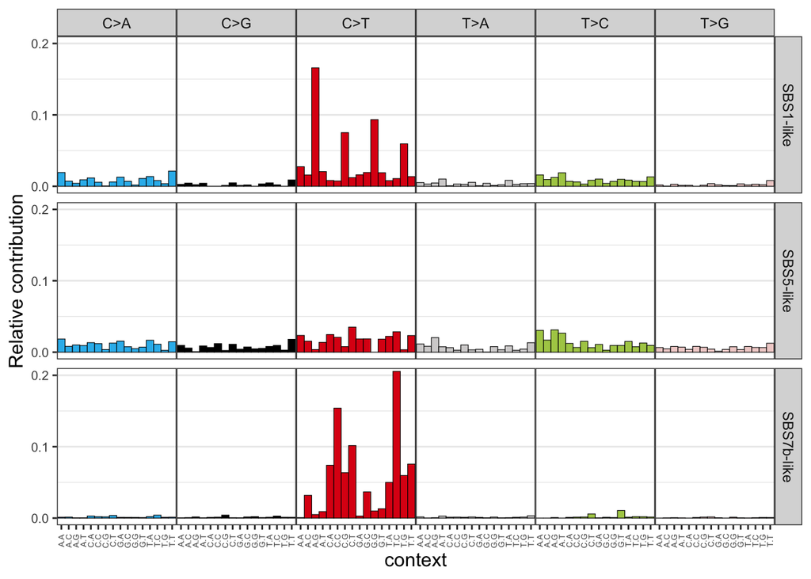

```r
# You can plot the 96-profile of the signatures (When looking at SNVs)
plot_96_profile(nmf_res$signatures, condensed = TRUE)
```

#### Decomposing our initial samples with the new signatures

The process of signature refitting involves measuring the impact of a specific set of signatures on the mutational profile of a sample. This is particularly valuable when analyzing mutational signatures in small groups or individual samples, as well as for comparing one’s own findings with established signatures and published research.

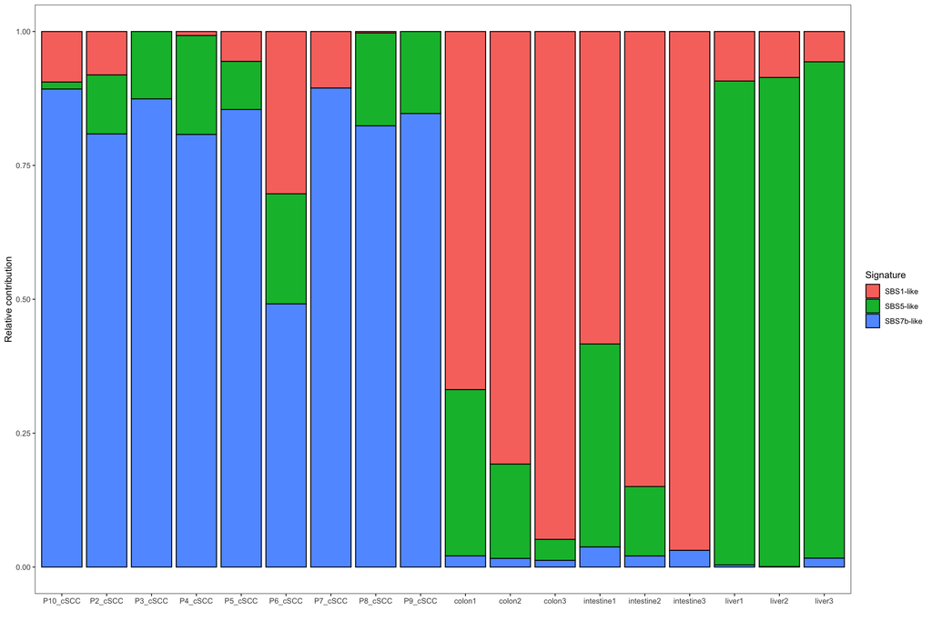

```r
# You can visualize the contribution of the signatures in a barplot
plot_contribution(nmf_res$contribution, nmf_res$signature,
                  mode = "relative"
)
```

#### Evaluating the performance of the reconstruction using our new signatures

One of the most used methods for quantifying the performance of mutational signature analysis is using the [cosine similarity](https://www.sciencedirect.com/topics/computer-science/cosine-similarity#:~:text=Cosine%20similarity%20measures%20the%20similarity,document%20similarity%20in%20text%20analysis.). This is a measure used to quantify the similarity between two signature vectors. The cosine similarity calculates the cosine of the angle between two signature vectors, which indicates the degree of similarity or alignment between them.

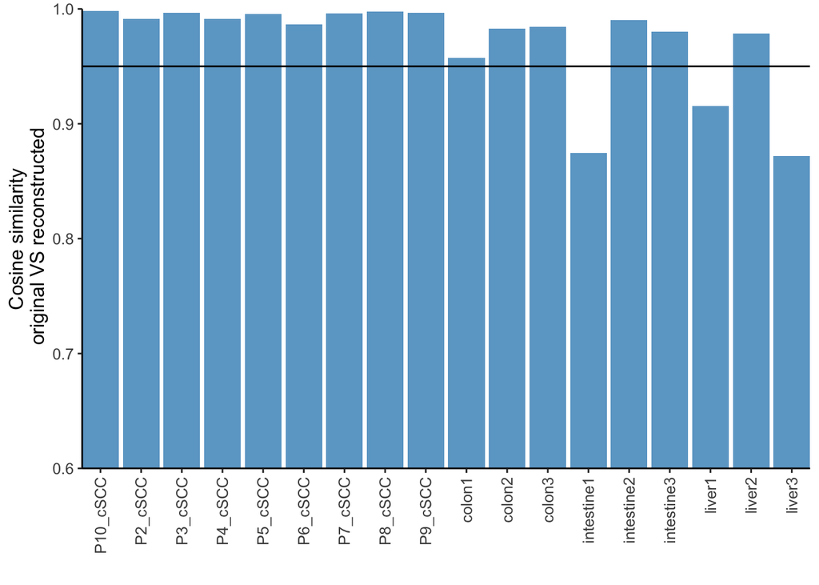

```r
# Check the reconstruction
Plot_reconstruciton_cos_sim <- plot_original_vs_reconstructed(mut_mat, nmf_res$reconstructed,y_intercept = 0.95)
Plot_reconstruciton_cos_sim
```

#### Are these signatures and patterns different across samples?

This function clusters the samples and signatures based on the different contribution. This is quite interesting if we want to compare samples between them, and check the different mutational processes working on each.

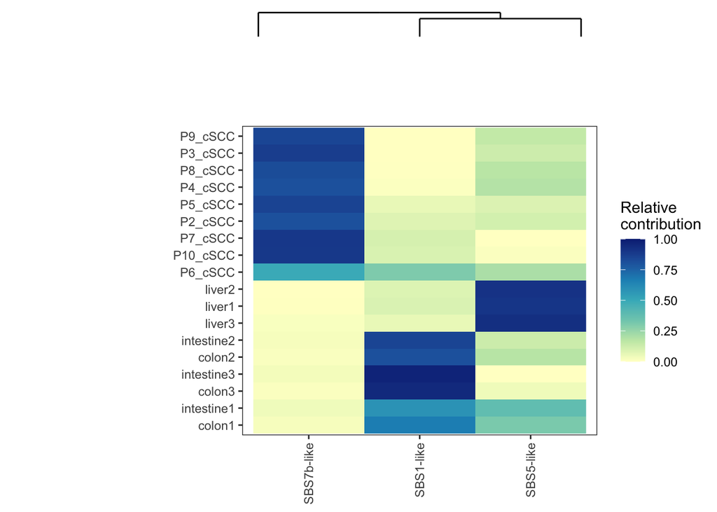

```r
# Check how the samples cluster
plot_contribution_heatmap(nmf_res$contribution,
                          cluster_samples = TRUE,
                          cluster_sigs = TRUE)
```

We can do it as well numerically by computing the cosine similarity between samples:

```r
# Comparison of samples between them
cos_sim_samples_signatures2 <- cos_sim_matrix(mut_mat, mut_mat)
cos_sim_samples_signatures2
```

```
##             P10_cSCC   P2_cSCC   P3_cSCC   P4_cSCC   P5_cSCC   P6_cSCC
## P10_cSCC   1.0000000 0.9901060 0.9928650 0.9863634 0.9964841 0.9639042
## P2_cSCC    0.9901060 1.0000000 0.9814704 0.9829282 0.9869052 0.9697875
## P3_cSCC    0.9928650 0.9814704 1.0000000 0.9891175 0.9921475 0.9523042
## P4_cSCC    0.9863634 0.9829282 0.9891175 1.0000000 0.9828901 0.9627825
## P5_cSCC    0.9964841 0.9869052 0.9921475 0.9828901 1.0000000 0.9562445
## P6_cSCC    0.9639042 0.9697875 0.9523042 0.9627825 0.9562445 1.0000000
## P7_cSCC    0.9927410 0.9830278 0.9896551 0.9859328 0.9878828 0.9708634
## P8_cSCC    0.9948969 0.9862465 0.9951859 0.9866427 0.9959123 0.9583529
## P9_cSCC    0.9955033 0.9889706 0.9886123 0.9854189 0.9898416 0.9657782
## colon1     0.3969216 0.4315853 0.3618840 0.3854721 0.3848758 0.5659135
## colon2     0.3618787 0.3903672 0.3135416 0.3365183 0.3491531 0.5263252
## colon3     0.3364617 0.3693390 0.2939608 0.3104668 0.3290736 0.4913235
## intestine1 0.4234029 0.4604582 0.4041645 0.4262962 0.4127611 0.5523484
## intestine2 0.3829863 0.4203417 0.3439077 0.3577943 0.3783210 0.5374735
## intestine3 0.3453728 0.3836924 0.3038503 0.3258188 0.3396872 0.5043696
## liver1     0.5102477 0.5292653 0.5068961 0.5430940 0.5065390 0.6041853
## liver2     0.5212126 0.5419998 0.4980517 0.5399553 0.5089448 0.6103083
## liver3     0.5639380 0.5739337 0.5657500 0.5739667 0.5569158 0.6238324
##              P7_cSCC   P8_cSCC   P9_cSCC    colon1    colon2    colon3
## P10_cSCC   0.9927410 0.9948969 0.9955033 0.3969216 0.3618787 0.3364617
## P2_cSCC    0.9830278 0.9862465 0.9889706 0.4315853 0.3903672 0.3693390
## P3_cSCC    0.9896551 0.9951859 0.9886123 0.3618840 0.3135416 0.2939608
## P4_cSCC    0.9859328 0.9866427 0.9854189 0.3854721 0.3365183 0.3104668
## P5_cSCC    0.9878828 0.9959123 0.9898416 0.3848758 0.3491531 0.3290736
## P6_cSCC    0.9708634 0.9583529 0.9657782 0.5659135 0.5263252 0.4913235
## P7_cSCC    1.0000000 0.9907145 0.9926438 0.4252891 0.3832772 0.3561595
## P8_cSCC    0.9907145 1.0000000 0.9928866 0.3778879 0.3317837 0.3097294
## P9_cSCC    0.9926438 0.9928866 1.0000000 0.3908579 0.3573998 0.3279756
## colon1     0.4252891 0.3778879 0.3908579 1.0000000 0.9539830 0.9148910
## colon2     0.3832772 0.3317837 0.3573998 0.9539830 1.0000000 0.9545902
## colon3     0.3561595 0.3097294 0.3279756 0.9148910 0.9545902 1.0000000
## intestine1 0.4393099 0.4112063 0.4266866 0.8279875 0.8071198 0.8283028
## intestine2 0.3995893 0.3632151 0.3780926 0.9320314 0.9628351 0.9742689
## intestine3 0.3693686 0.3251353 0.3436944 0.9108449 0.9401001 0.9618059
## liver1     0.5221512 0.5114360 0.5180748 0.6241417 0.5486596 0.5386759
## liver2     0.5233509 0.5173589 0.5380936 0.6133309 0.5734982 0.5363386
## liver3     0.5645221 0.5696388 0.5715016 0.5534931 0.4867102 0.4630024
##            intestine1 intestine2 intestine3    liver1    liver2    liver3
## P10_cSCC    0.4234029  0.3829863  0.3453728 0.5102477 0.5212126 0.5639380
## P2_cSCC     0.4604582  0.4203417  0.3836924 0.5292653 0.5419998 0.5739337
## P3_cSCC     0.4041645  0.3439077  0.3038503 0.5068961 0.4980517 0.5657500
## P4_cSCC     0.4262962  0.3577943  0.3258188 0.5430940 0.5399553 0.5739667
## P5_cSCC     0.4127611  0.3783210  0.3396872 0.5065390 0.5089448 0.5569158
## P6_cSCC     0.5523484  0.5374735  0.5043696 0.6041853 0.6103083 0.6238324
## P7_cSCC     0.4393099  0.3995893  0.3693686 0.5221512 0.5233509 0.5645221
## P8_cSCC     0.4112063  0.3632151  0.3251353 0.5114360 0.5173589 0.5696388
## P9_cSCC     0.4266866  0.3780926  0.3436944 0.5180748 0.5380936 0.5715016
## colon1      0.8279875  0.9320314  0.9108449 0.6241417 0.6133309 0.5534931
## colon2      0.8071198  0.9628351  0.9401001 0.5486596 0.5734982 0.4867102
## colon3      0.8283028  0.9742689  0.9618059 0.5386759 0.5363386 0.4630024
## intestine1  1.0000000  0.8685395  0.8419301 0.6614297 0.6131328 0.5410043
## intestine2  0.8685395  1.0000000  0.9650489 0.5757084 0.5859067 0.5083698
## intestine3  0.8419301  0.9650489  1.0000000 0.5233512 0.5211251 0.4105802
## liver1      0.6614297  0.5757084  0.5233512 1.0000000 0.8639384 0.7644462
## liver2      0.6131328  0.5859067  0.5211251 0.8639384 1.0000000 0.8136824
## liver3      0.5410043  0.5083698  0.4105802 0.7644462 0.8136824 1.0000000
```